# Causal Inference

Topics

Macartan Humphreys

# 1 Observational designs

*Introduction to observational strategies using `DeclareDesign`*

## 1.1 Outline

- LATE
- Diff in Diff
- RDD

## 1.2 Noncompliance and the LATE estimand

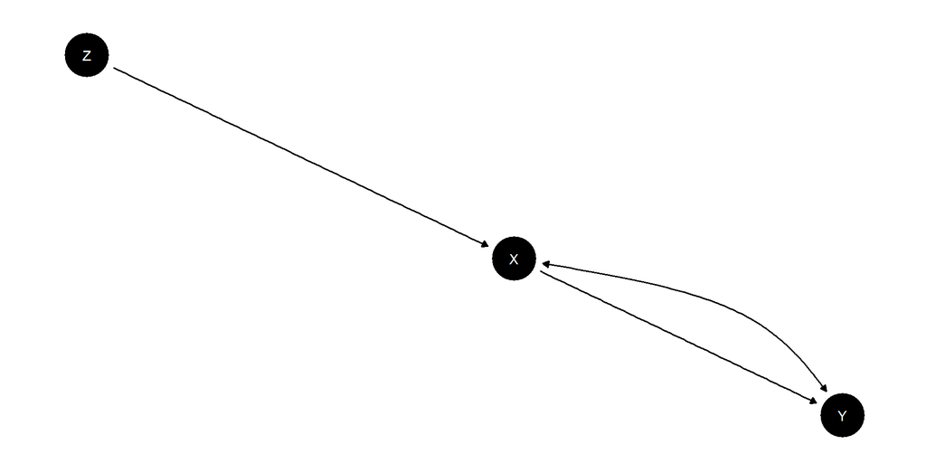

### 1.2.1 Local Average Treatment Effects

Sometimes you give a medicine but only a nonrandom sample of people actually try to use it. Can you still estimate the medicine’s effect?

|  | X=0 | X=1 |
| --- | --- | --- |
| Z=0 | $\overline{y}_{00}$ ($n_{00}$) | $\overline{y}_{01}$ ($n_{01}$) |
| Z=1 | $\overline{y}_{10}$ ($n_{10}$) | $\overline{y}_{11}$ ($n_{11}$) |

Say that people are one of 3 types:

1. $n_a$ “always takers” have $X=1$ no matter what and have average outcome $\overline{y}_a$
2. $n_n$ “never takers” have $X=0$ no matter what with outcome $\overline{y}_n$
3. $n_c$ “compliers have” $X=Z$ and average outcomes $\overline{y}^1_c$ if treated and $\overline{y}^0_c$ if not.

### 1.2.2 Local Average Treatment Effects

Sometimes you give a medicine but only a non random sample of people actually try to use it. Can you still estimate the medicine’s effect?

|  | X=0 | X=1 |
| --- | --- | --- |
| Z=0 | $\overline{y}_{00}$ ($n_{00}$) | $\overline{y}_{01}$ ($n_{01}$) |
| Z=1 | $\overline{y}_{10}$ ($n_{10}$) | $\overline{y}_{11}$ ($n_{11}$) |

We can figure something about types:

|  | $X=0$ | $X=1$ |
| --- | --- | --- |
| $Z=0$ | $\frac{\frac{1}{2}n_c}{\frac{1}{2}n_c + \frac{1}{2}n_n} \overline{y}^0_{c}+\frac{\frac{1}{2}n_n}{\frac{1}{2}n_c + \frac{1}{2}n_n} \overline{y}_{n}$ | $\overline{y}_{a}$ |
| $Z=1$ | $\overline{y}_{n}$ | $\frac{\frac{1}{2}n_c}{\frac{1}{2}n_c + \frac{1}{2}n_a} \overline{y}^1_{c}+\frac{\frac{1}{2}n_a}{\frac{1}{2}n_c + \frac{1}{2}n_a} \overline{y}_{a}$ |

### 1.2.3 Local Average Treatment Effects

You give a medicine to 50% but only a non random sample of people actually try to use it. Can you still estimate the medicine’s effect?

|  | $X=0$ | $X=1$ |
| --- | --- | --- |
| $Z=0$ | $\frac{n_c}{n_c + n_n} \overline{y}^0_{c}+\frac{n_n}{n_c + n_n} \overline{y}_n$ | $\overline{y}_{a}$ |
| (n) | ($\frac{1}{2}(n_c + n_n)$) | ($\frac{1}{2}n_a$) |
| $Z=1$ | $\overline{y}_{n}$ | $\frac{n_c}{n_c + n_a} \overline{y}^1_{c}+\frac{n_a}{n_c + n_a} \overline{y}_{a}$ |
| (n) | ($\frac{1}{2}n_n$) | ($\frac{1}{2}(n_a+n_c)$) |

Key insight: the contributions of the $a$s and $n$s are the *same* in the $Z=0$ and $Z=1$ groups so if you difference you are left with the *changes* in the contributions of the $c$s.

### 1.2.4 Local Average Treatment Effects

Average in $Z=0$ group: $\frac{{n_c} \overline{y}^0_{c}+ \left(n_{n}\overline{y}_{n} +{n_a} \overline{y}_a\right)}{n_a+n_c+n_n}$

Average in $Z=1$ group: $\frac{{n_c} \overline{y}^1_{c} + \left(n_{n}\overline{y}_{n} +{n_a} \overline{y}_a \right)}{n_a+n_c+n_n}$

So, the *difference* is the ITT: $({\overline{y}^1_c-\overline{y}^0_c})\frac{n_c}{n}$

Last step:

$$ITT = ({\overline{y}^1_c-\overline{y}^0_c})\frac{n_c}{n}$$

$$\leftrightarrow$$

$$LATE = \frac{ITT}{\frac{n_c}{n}}= \frac{\text{Intent to treat effect}}{\text{First stage effect}}$$

### 1.2.5 The good and the bad of LATE

- (with infinite data) You get a good estimate even when there is non-random take-up
- May sometimes be used to assess mediation or knock-on effects
- But:
  - You need assumptions (monotonicity and the exclusion restriction – *where were these used above*?)
  - Your estimate is only for a subpopulation
  - The subpopulation is not chosen by you and is unknown
  - Different encouragements may yield different estimates since they may encourage different subgroups

### 1.2.6 Declaration

```r
declaration_iv <-
  declare_model(
    N = 100,
    U = rnorm(N),
    potential_outcomes(D ~ if_else(Z + U > 0, 1, 0),
                       conditions = list(Z = c(0, 1))),
    potential_outcomes(Y ~ 0.1 * D + 0.25 + U,
                       conditions = list(D = c(0, 1))),
    complier = D_Z_1 == 1 & D_Z_0 == 0
  ) +
  declare_inquiry(ATE = mean(Y_D_1 - Y_D_0),
                  LATE = mean(Y_D_1[complier] - Y_D_0[complier])) +
  declare_assignment(Z = complete_ra(N, prob = 0.5)) +
  declare_measurement(D = reveal_outcomes(D ~ Z),
                      Y = reveal_outcomes(Y ~ D)) +
  declare_estimator(Y ~ D, inquiry = "ATE", label = "OLS")  +
  declare_estimator(Y ~ D | Z, .method = iv_robust, inquiry = "LATE",
                    label = "IV")
```

### 1.2.7 Diagnosis

| Inquiry | Estimator | Mean Estimand | Mean Estimate | Bias | RMSE |
| --- | --- | --- | --- | --- | --- |
| ATE | OLS | 0.10 | 1.55 | 1.45 | 1.46 |
|  |  | (0.00) | (0.00) | (0.00) | (0.00) |
| LATE | IV | 0.10 | -0.05 | -0.15 | 0.80 |
|  |  | (0.00) | (0.01) | (0.01) | (0.03) |

Note:

- The estimands *might* be the same
- The estimators might both be biased
- And in opposite directions

## 1.3 Diff in diff

Key idea: the evolution of units in the control group allow you to impute what the evolution of units in the treatment group *would have been* had they not been treated

### 1.3.1 Logic

We have group $A$ that enters treatment at some point and group $B$ that never does

The estimate:

$$\hat\tau = (\mathbb{E}[Y^A | post] - \mathbb{E}[Y^A | pre]) -(\mathbb{E}[Y^B | post] - \mathbb{E}[Y^B | pre])$$
(how different is the change in $A$ compared to the change in $B$?)

can be written *using potential outcomes as*:

$$\hat\tau = (\mathbb{E}[Y_1^A | post] - \mathbb{E}[Y_0^A | pre]) -(\mathbb{E}[Y_0^B | post] - \mathbb{E}[Y_0^B | pre])$$

### 1.3.2 Logic

With some manipulation and cleaning up:

$$\hat\tau = (\mathbb{E}[Y_1^A | post] - \mathbb{E}[Y_0^A | pre]) -(\mathbb{E}[Y_0^B | post] - \mathbb{E}[Y_0^B | pre])$$

$$
$$\begin{aligned}
\hat\tau = (\mathbb{E}[Y_1^A | post] - \color{red}{\mathbb{E}[Y_0^A | post]}) + ((\color{red}{\mathbb{E}[Y_0^A | post]} - \mathbb{E}[Y_0^A | pre]) -(\mathbb{E}[Y_0^B | post] - \mathbb{E}[Y_0^B | pre]))
\end{aligned}$$

$$

$$\hat\tau_{ATT} = \tau_{ATT} + \text{Difference in trends}$$

### 1.3.3 Simplest DiD: Design

```r
n_units <- 2
design <-
  declare_model(
    unit = add_level(N = n_units, I = 1:N),
    time = add_level(N = 6, T = 1:N, nest = FALSE),
    obs = cross_levels(by = join_using(unit, time))) +
  declare_model(potential_outcomes(Y ~ I + T^.5 + Z*T)) +
  declare_assignment(Z = 1*(I>(n_units/2))*(T>3)) +
  declare_measurement(Y = reveal_outcomes(Y~Z)) +
  declare_inquiry(ATE = mean(Y_Z_1 - Y_Z_0),
                  ATT = mean(Y_Z_1[Z==1] - Y_Z_0[Z==1])) +
  declare_estimator(Y ~ Z, label = "naive") +
  declare_estimator(Y ~ Z + I, label = "FE1") +
  declare_estimator(Y ~ Z + as.factor(T), label = "FE2") +
  declare_estimator(Y ~ Z + I + as.factor(T), label = "FE3")
```

### 1.3.4 Simplest DiD: Data

```r
draw_data(design) |>
  head() |> kable()
```

| unit | I | time | T | obs | Y_Z_0 | Y_Z_1 | Z | Y |
| --- | --- | --- | --- | --- | --- | --- | --- | --- |
| 1 | 1 | 1 | 1 | 01 | 2.000000 | 3.000000 | 0 | 2.000000 |
| 2 | 2 | 1 | 1 | 02 | 3.000000 | 4.000000 | 0 | 3.000000 |
| 1 | 1 | 2 | 2 | 03 | 2.414214 | 4.414214 | 0 | 2.414214 |
| 2 | 2 | 2 | 2 | 04 | 3.414214 | 5.414214 | 0 | 3.414214 |
| 1 | 1 | 3 | 3 | 05 | 2.732051 | 5.732051 | 0 | 2.732051 |
| 2 | 2 | 3 | 3 | 06 | 3.732051 | 6.732051 | 0 | 3.732051 |

### 1.3.5 Simplest DiD: Diagnosis

Here only the two way fixed effects is unbiased and only for the ATT.

The ATT here is averaging over effects for treated units (later periods only). We *know nothing* about the size of effects in earlier periods when all units are in control!

```r
design |> diagnose_design()
```

| Inquiry | Estimator | Bias |
| --- | --- | --- |
| ATE | FE1 | 2.25 |
| ATE | FE2 | 6.50 |
| ATE | FE3 | 1.50 |
| ATE | naive | 5.40 |
| ATT | FE1 | 0.75 |
| ATT | FE2 | 5.00 |
| ATT | FE3 | 0.00 |
| ATT | naive | 3.90 |

### 1.3.6 The classic graph

```r
design |>
  draw_data() |>
  ggplot(aes(T, Y, color = unit)) + geom_line() +
       geom_point(aes(T, Y_Z_0)) + theme_bw()
```

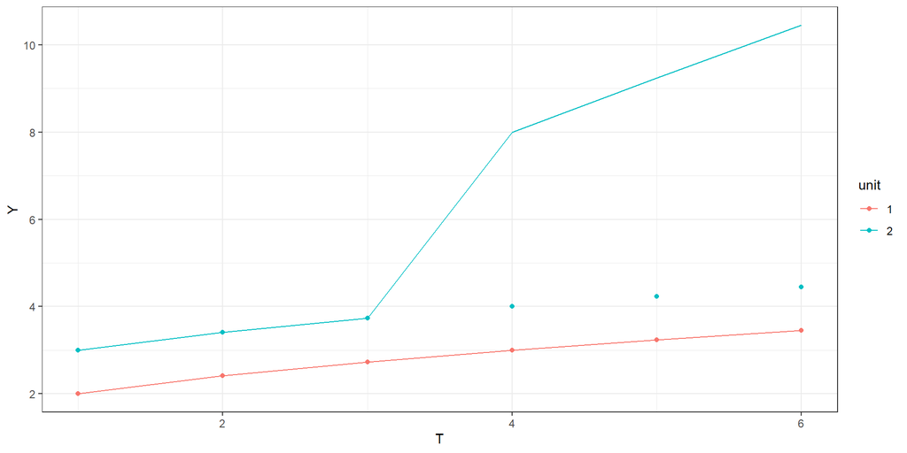

### 1.3.7 Extends to multiple units easily

```r
design |> redesign(n_units = 10) |> diagnose_design()
```

[output not shown]

### 1.3.8 Extends to multipe units easily

```r
design |>
  redesign(n_units = 10) |>
  draw_data() |>
  ggplot(aes(T, Y, color = unit)) + geom_line() +
       geom_point(aes(T, Y_Z_0)) + theme_bw()
```

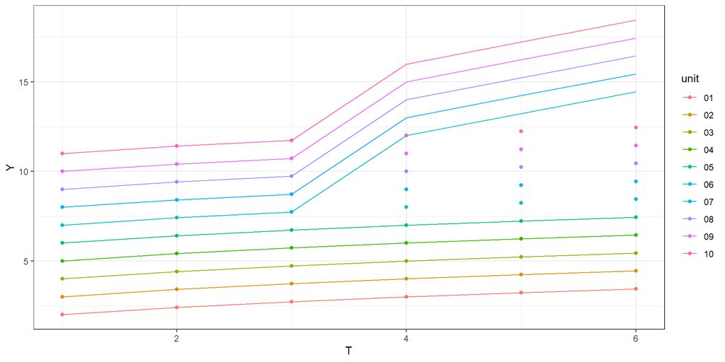

### 1.3.9 In practice

- Need to defend parallel trends
- Most typically using an *event study*
- Sometimes: report balance between treatment and control groups in covariates
- Placebo leads and lags

### 1.3.10 Heterogeneity

- Things get much more complicated when there is (a) heterogeneous timing in treatment take up and (b) heterogeneous effects
- It’s only recently been appreciated how tricky things can get
- But we already have an intuition from our analysis of trials with heterogeneous assignment and heterogeneous effects:
- in such cases fixed effects analysis weights stratum level treatment effects by the variance in assignment to treatment
- something similar here

### 1.3.11 Staggared assignments

Just two units assigned at different times:

```r
trend = 0

design <-
  declare_model(
    unit = add_level(N = 2, ui = rnorm(N), I = 1:N),
    time = add_level(N = 6, ut = rnorm(N), T = 1:N, nest = FALSE),
    obs = cross_levels(by = join_using(unit, time))) +
  declare_model(
    potential_outcomes(Y ~ trend*T + (1+Z)*(I == 2))) +
  declare_assignment(Z = 1*((I == 1) * (T>3) + (I == 2) * (T>5))) +
  declare_measurement(Y = reveal_outcomes(Y~Z),
                      I_c = I - mean(I)) +
  declare_inquiry(mean(Y_Z_1 - Y_Z_0)) +
  declare_estimator(Y ~ Z, label = "1. naive") +
  declare_estimator(Y ~ Z + I, label = "2. FE1") +
  declare_estimator(Y ~ Z + as.factor(T), label = "3. FE2") +
  declare_estimator(Y ~ Z + I + as.factor(T), label = "4. FE3") +
  declare_estimator(Y ~ Z*I_c + as.factor(T), label = "5. Sat")
```

### 1.3.12 Staggared assignments diagnosis

| Estimator | Mean Estimand | Mean Estimate |
| --- | --- | --- |
| 1. naive | 0.50 | -0.12 |
|  | (0.00) | (0.00) |
| 2. FE1 | 0.50 | 0.36 |
|  | (0.00) | (0.00) |
| 3. FE2 | 0.50 | -1.00 |
|  | (0.00) | (0.00) |
| 4. FE3 | 0.50 | 0.25 |
|  | (0.00) | (0.00) |
| 5. Sat | 0.50 | 0.50 |
|  | (0.00) | (0.00) |

See [causal inference](https://macartan.github.io/ci/ci_2024.html#/where-do-these-numbers-come) slides for intuitions on what is happening here as well as declaration using approach of Chaisemartin and d’Haultfoeuille (2020).

## 1.4 Regression discontintuity

Errors and diagnostics

### 1.4.1 Intuition

- The core idea in an RDD design is that if a decision rule assigns units that are *almost identical* to each other to treatment and control conditions then we can infer effects *for those cases*<sup>1</sup> by looking *at those cases*.

See excellent introduction: Lee and Lemieux (2010)

[^1]: though when we look at the estimand definition you will see that’s not exactly right

### 1.4.2 Intuition

- Kids born on 31 August start school a year younger than kids born on 1 September: does starting younger help or hurt?
- Kids born on 12 September 1983 are more likely to register Republican than kids born on 10 September 1983: can this identify the effects of registration on long term voting?
- A district in which Republicans got 50.1% of the vote get a Republican representative while districts in which Republicans got 49.9% of the vote do not: does having a Republican representative make a difference for these districts?

### 1.4.3 Argument for identification

Setting:

- Typically the decision is based on a value on a “running variable”, $X$. e.g. Treatment if $X > 0$
- The estimand is $\mathbb{E}[Y(1) - Y(0)|X=0]$

Two arguments:

1. Continuity: $\mathbb{E}[Y(1)|X=x]$ and $\mathbb{E}[Y(0)|X=x]$ are continuous (at $x=0$) in $x$: so $\lim_{\hat x \rightarrow 0}\mathbb{E}[Y(0)|X=\hat x] = \mathbb{E}[Y(0)|X=\hat 0]$
2. Local randomization: tiny things that determine exact values of $x$ are *as if* random and so we can think of a local experiment around $X=0$.

### 1.4.4 Argument for identification

Note:

- continuity argument requires continuous $x$: granularity
- also builds off a conditional expectation function defined at $X=0$

Exclusion restriction is *implicit* in continuity: If *something else* happens at the threshold then the conditional expectation functions jump at the thresholds

Implicit: $X$ is exogenous in the sense that units cannot adjust $X$ in order to be on one or the other side of the threshold

### 1.4.5 Evidence

Typically researchers show:

1. “First stage” results: assignment to treatment does indeed jump at the threshold
2. “ITT”: outcomes jump at the threshold
3. LATE (if fuzzy / imperfect compliance) using IV

### 1.4.6 Evidence

Typically researchers show:

In addition:

1. Arguments for no other treatments at the threshold
2. Arguments for no “sorting” at the threshold
3. Evidence for no “heaping” at the threshold (McCrary density test)

Sometimes:

- argue for why estimates extend beyond the threshold
- exclude points *at* the threshold (!)

### 1.4.7 Design

```r
library(rdss) # for helper functions
library(rdrobust)

cutoff <- 0.5
bandwidth <- 0.5

control <- function(X) {
  as.vector(poly(X, 4, raw = TRUE) %*% c(.7, -.8, .5, 1))}
treatment <- function(X) {
  as.vector(poly(X, 4, raw = TRUE) %*% c(0, -1.5, .5, .8)) + .25}

rdd_design <-
  declare_model(
    N = 1000,
    U = rnorm(N, 0, 0.1),
    X = runif(N, 0, 1) + U - cutoff,
    D = 1 * (X > 0),
    Y_D_0 = control(X) + U,
    Y_D_1 = treatment(X) + U
  ) +
  declare_inquiry(LATE = treatment(0) - control(0)) +
  declare_measurement(Y = reveal_outcomes(Y ~ D)) +
  declare_sampling(S = X > -bandwidth & X < bandwidth) +
  declare_estimator(Y ~ D*X, term = "D", label = "lm") +
  declare_estimator(
    Y, X,
    term = "Bias-Corrected",
    .method = rdrobust_helper,
    label = "optimal"
  )
```

### 1.4.8 RDD Data plotted

Note `rdrobust` implements:

- local polynomial Regression Discontinuity (RD) point estimators
- robust bias-corrected confidence intervals

See Calonico, Cattaneo, and Titiunik (2014) and related papers `? rdrobust::rdrobust`

### 1.4.9 RDD Data plotted

```r
rdd_design  |> draw_data() |>
  ggplot(aes(X, Y, color = factor(D))) +
  geom_point(alpha = .3) + theme_bw()+ theme(legend.position = "none") +
  geom_smooth(aes(X, Y_D_0)) + geom_smooth(aes(X, Y_D_1))
```

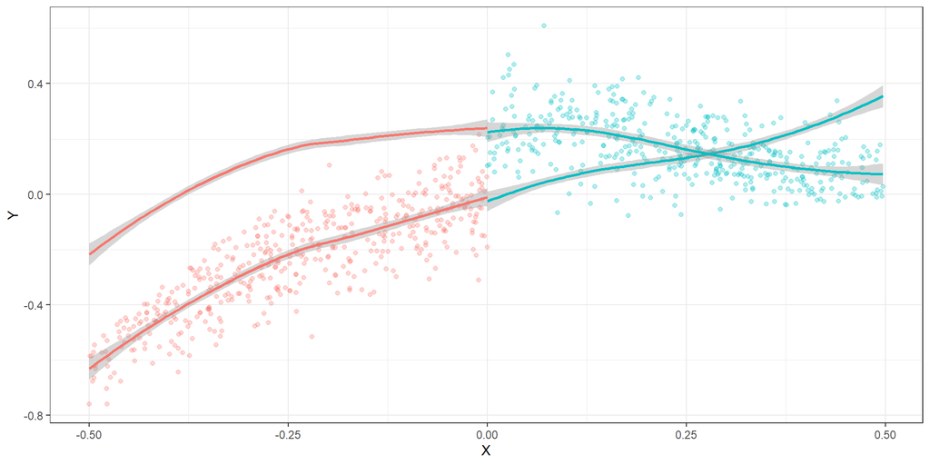

### 1.4.10 RDD diagnosis

```r
rdd_design |> diagnose_design()
```

| Estimator | Mean Estimate | Bias | SD Estimate | Coverage |
| --- | --- | --- | --- | --- |
| lm | 0.23 | -0.02 | 0.01 | 0.64 |
|  | (0.00) | (0.00) | (0.00) | (0.02) |
| optimal | 0.25 | 0.00 | 0.03 | 0.89 |
|  | (0.00) | (0.00) | (0.00) | (0.01) |

### 1.4.11 Bandwidth tradeoff

```r
rdd_design |>
  redesign(bandwidth = seq(from = 0.05, to = 0.5, by = 0.05)) |>
  diagnose_designs()
```

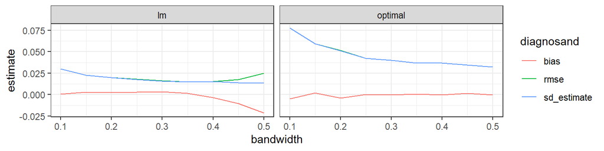

- As we increase the bandwidth, the lm bias gets worse, but slowly, while the error falls.
- The best bandwidth is relatively wide.
- This is more true for the optimal estimator.

Calonico, Sebastian, Matias D Cattaneo, and Rocio Titiunik. 2014. “Robust Nonparametric Confidence Intervals for Regression-Discontinuity Designs.” *Econometrica* 82 (6): 2295–2326.

Lee, David S, and Thomas Lemieux. 2010. “Regression Discontinuity Designs in Economics.” *Journal of Economic Literature* 48 (2): 281–355.